# Part II - (FordGo Bike Trip Data Presentation)

## by (Bello Victor)

## Investigation Overview

> The goal of this presentation is to provide insight on the FordGo Bike Trip data. The exploration of this dataset has been conducted and insights deduced. The important findings include: the generation distribution of people that take the bike rides, the proportion of riders that share bikes and the duration distribution of rides with regards to type of gender.

## Dataset Overview

> The data set includes information about individual rides made in a bike-sharing system covering the greater San Francisco Bay area. It has 183412 rows and 16 columns. Among the variables recorded are: start time, end time, station name, station latitude and longitude.

## Visualization 1

> It is infered from the data exploration phase that the generation that takes the most bike rides stem from the 1980's, the year 1988 to be precise. Armed with this information, it is safe to conclude that the distribution of individuals that embark on these bike trips are predominantly below middle age.

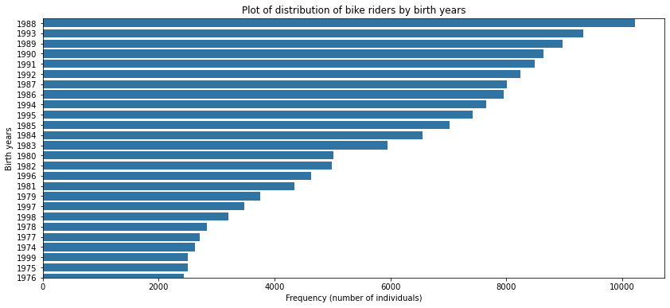

## Visualization 2

> I discovered from the dataset explored that the percentage of riders who shared their bikes were significantly less than the the riders who did not share.

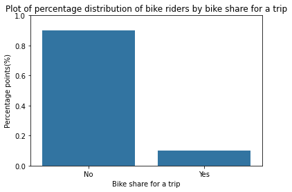

## Visualization 3

> I as well discovered that the duration of travel for the type of genders had no discernible variability. This is interesting that the data explored indicated that.

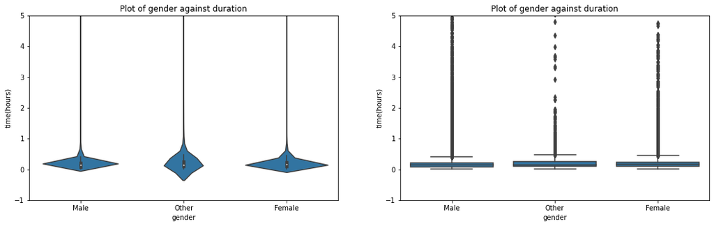